# Exploratory Data Analysis by Irena Trendafilova

# Intro

Prosper is the market leader in peer-to-peer lending (a popular alternative to traditional loans and investing options).

Here’s how it works: (www.prosper.com)

- **Borrowers** choose a loan amount, purpose and post a loan listing.
- **Investors** review loan listings and invest in loans that meet their criteria.
- **Once the process is complete**, borrowers make fixed monthly payments and investors receive a portion of those payments directly to their Prosper account.

**Analysis Process Overview**

**First**, I spent some time to understand the Prosper business process. What helped me the most here, was the Prosper website.

**Second**, I focused on clarifying the meaning of each variable. I spent a lot of time on understanding variables and values stored in each variable.

My main idea was to classify them, then eliminate some of the variables that will not give me useful info about this data set and to create new variables. Classification and elimination helped me to reduce the number of available variables and focus on main features of interest in my analysis.

**Third**, I’ve analyzed the variables, by asking my self simple questions, plotting the variables and understanding how these variables are related.

Here is the summary of my analysis.

# Summary of the Data Set

This data set contains 113937 loans with 81 variables on each loan:

```
## [1] 113937     81
```

Here are the names of all the 81 variables:

```
##  [1] "ListingKey"
##  [2] "ListingNumber"
##  [3] "ListingCreationDate"
##  [4] "CreditGrade"
##  [5] "Term"
##  [6] "LoanStatus"
##  [7] "ClosedDate"
##  [8] "BorrowerAPR"
##  [9] "BorrowerRate"
## [10] "LenderYield"
## [11] "EstimatedEffectiveYield"
## [12] "EstimatedLoss"
## [13] "EstimatedReturn"
## [14] "ProsperRating..numeric."
## [15] "ProsperRating..Alpha."
```

[output cut: 66 more lines]

Variables Overview:

```
## 'data.frame':    113937 obs. of  81 variables:
##  $ ListingKey                         : chr  "1021339766868145413AB3B" "10273602499503308B223C1" "0EE9337825851032864889A" "0EF5356002482715299901A" ...
##  $ ListingNumber                      : int  193129 1209647 81716 658116 909464 1074836 750899 768193 1023355 1023355 ...
##  $ ListingCreationDate                : chr  "2007-08-26 19:09:29.263000000" "2014-02-27 08:28:07.900000000" "2007-01-05 15:00:47.090000000" "2012-10-22 11:02:35.010000000" ...
##  $ CreditGrade                        : chr  "C" "" "HR" "" ...
##  $ Term                               : int  36 36 36 36 36 60 36 36 36 36 ...
##  $ LoanStatus                         : chr  "Completed" "Current" "Completed" "Current" ...
##  $ ClosedDate                         : chr  "2009-08-14 00:00:00" "" "2009-12-17 00:00:00" "" ...
##  $ BorrowerAPR                        : num  0.165 0.12 0.283 0.125 0.246 ...
##  $ BorrowerRate                       : num  0.158 0.092 0.275 0.0974 0.2085 ...
##  $ LenderYield                        : num  0.138 0.082 0.24 0.0874 0.1985 ...
##  $ EstimatedEffectiveYield            : num  NA 0.0796 NA 0.0849 0.1832 ...
##  $ EstimatedLoss                      : num  NA 0.0249 NA 0.0249 0.0925 ...
##  $ EstimatedReturn                    : num  NA 0.0547 NA 0.06 0.0907 ...
##  $ ProsperRating..numeric.            : int  NA 6 NA 6 3 5 2 4 7 7 ...
```

[output cut: 67 more lines]

# Univariate Plots Section

**What’s the time interval for loans available in this data set?**

Since the company was founded in 2005 and the last updated of this data set was on March 11th 2014, I just want to confirm that the range of the Listing Creation Dates is inside that time-frame interval.

```
## [1] "2005-11-09 20:44:28.847000000" "2014-03-10 12:20:53.760000000"
```

As we can see the first created listing is on 2005-11-09 and the last one is on 2014-03-10, which is the day before this data set was last updated.

During the variables understanding process, I’ve realized that some of the variables are applicable only for loans created after July 2009. So, I was curious to know what’s the number or percentage of those loans.

**How many loans were created before July 2009?**

```
## Number of loans created prior to July 1st 2009
## FALSE  TRUE
## 84853 29084
```

```
## Percentage of loans created prior to July 1st 2009
##    FALSE     TRUE
## 74.47361 25.52639
```

This means that for 29084 loans or 25.52% of loans records we don’t have values for some variables (example: ProsperScore, ProsperRating (numeric), ProsperRating (Alpha), EstimatedEffectiveYield, EstimatedLoss, EstimatedReturn).

**New variables and data frames**

Here are the additional variables and helper data frames I’ve created:

- Variables (ListingCreationYear, MonthlyDebt, EmploymentInfo, ListingCategoryName)
- Data frames (loansAfter20090701, loansBefore20090701)

**What’s the distribution of loans by year or by quarter?**

The first thing I analyzed was the financial stability of Prosper business. How their business was growing and were there any ups and downs between 2005 and 2014. Let’s see how are loans distributed over the years.

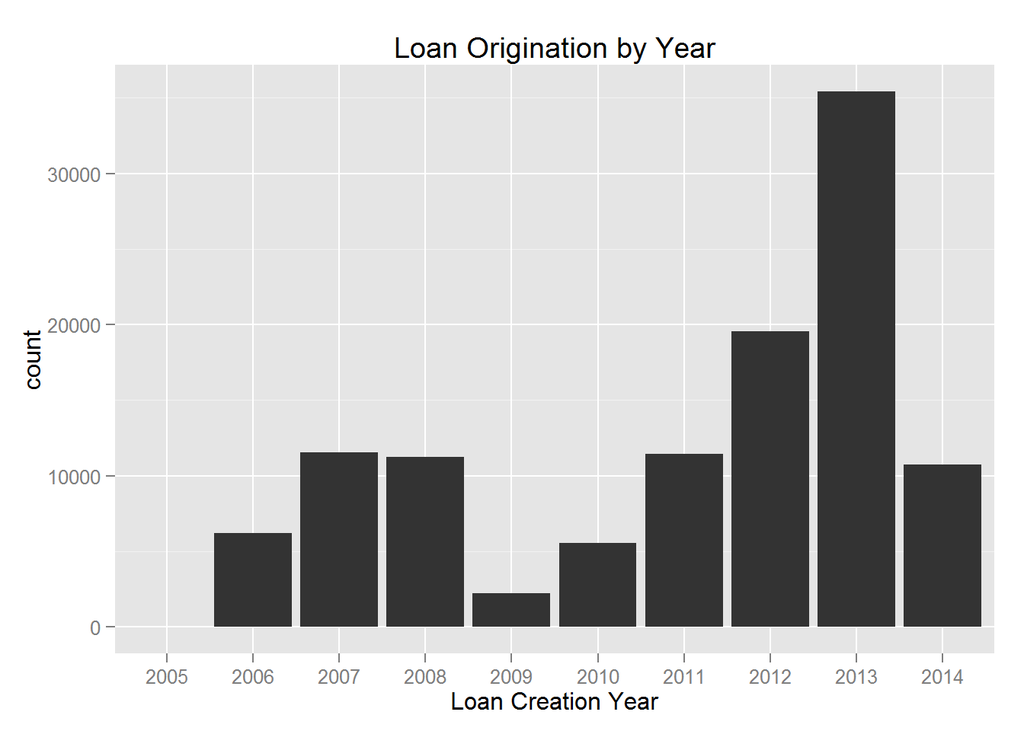

The number of loans created almost doubled from 2006 to 2007, then dropped a little in 2008 and decreased seriously in 2009. Definitely the main reason behind this number is the global financial crisis. Since 2009 the business started to recover every year. The business prospered at 2013. I want to mention that we don’t have all records for 2014.

**Let’s see how loans are distributed by quarters?**

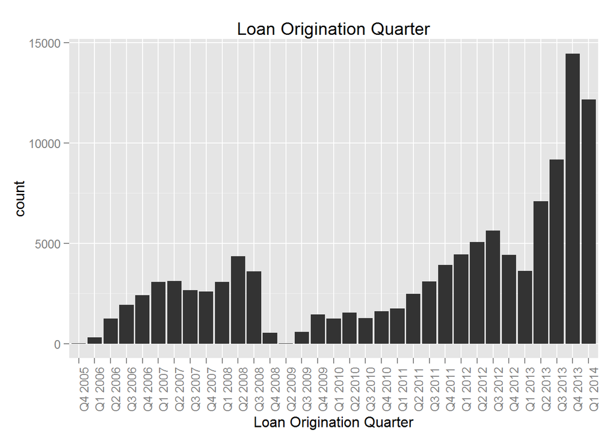

Definitely 2009 was the worst year for the Prosper business. There were no loans created in Q1 2009 and very few in Q2 2009. Again, my guess is that the global financial crisis was the main reason for those numbers. Q4 2013 was the best quarter ever. Even though we don’t have all data for Q1 2014 we can see that the business is still growing in positive direction.

Here is the first group of questions I asked my self. How much people are borrowing? What’s the most frequent term? What people borrow money for?

**How much people are borrowing?**

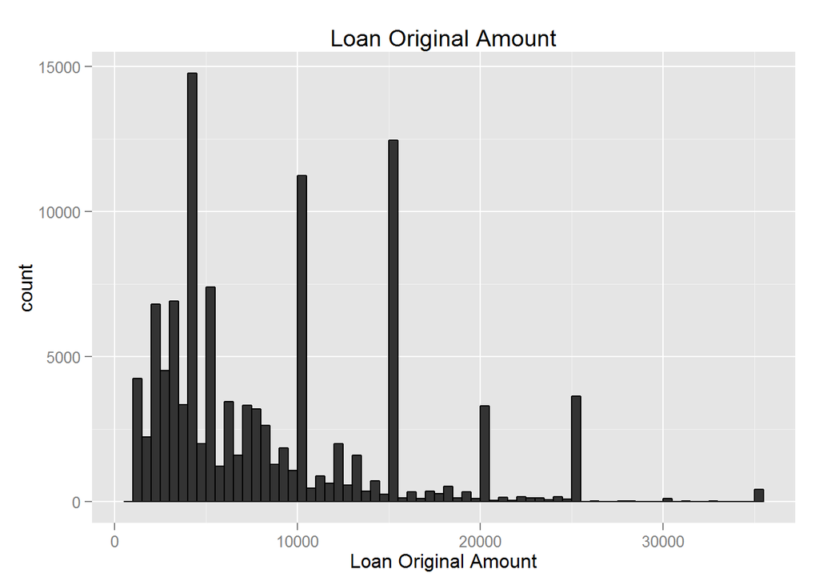

```
##    Min. 1st Qu.  Median    Mean 3rd Qu.    Max.
##    1000    4000    6500    8337   12000   35000
```

The minimum amount people are borrowing is $1000, maximum is $35000. Mean value is $8337 and median is $6500. We can see picks on amounts like $5000, $10000, $15000, $20000 and $25000 which is expected. Not much people borrowed $30000 or $35000 but again we have small picks there too.

If we change the binwidth to 5000, it clearly appears that the frequency globally decreases with the Amount increase.

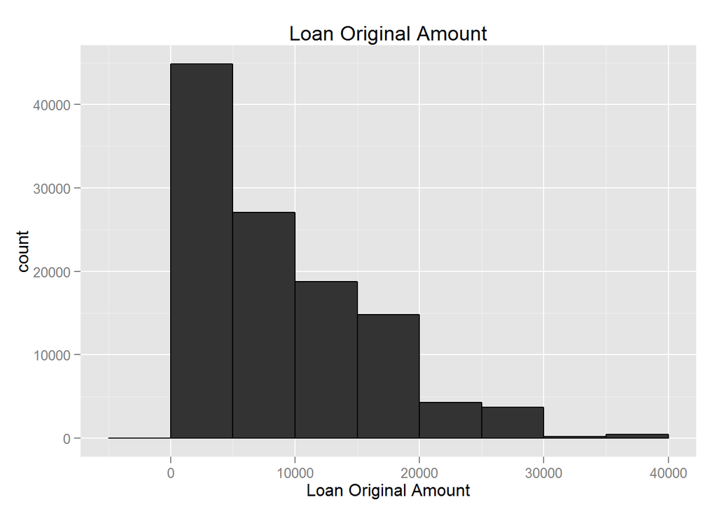

**What is the most frequent Term of loan?**

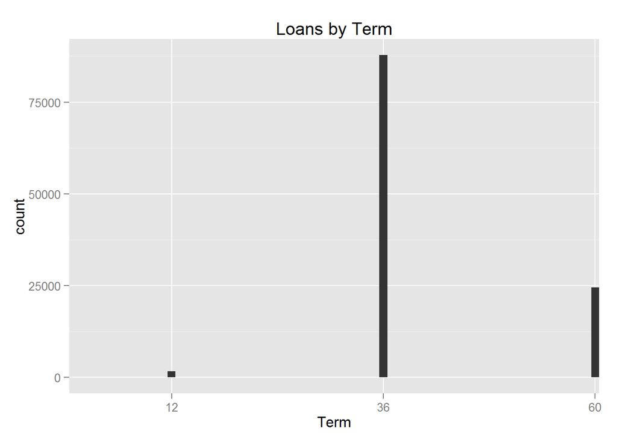

```
##
##    12    36    60
##  1614 87778 24545
```

```
##    Min. 1st Qu.  Median    Mean 3rd Qu.    Max.
##   12.00   36.00   36.00   40.83   36.00   60.00
```

The most frequent term is 36 months (3years). Only 1614 of the borrowers have chosen 1 year and 24545 have chosen 5 years. With 87778 of loans with 3 years term, surely that’s the most frequent choice.

**Let’s see what people borrow money for?**

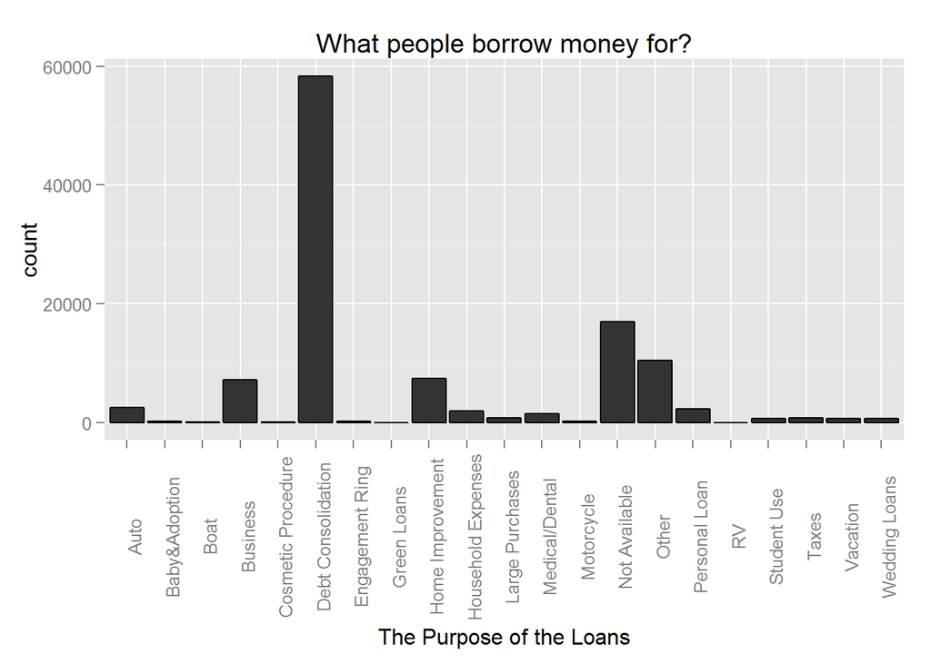

The leading loan category is Debt consolidation.

Again I want to check is there any relationship between the loan creation date and category being empty.

```
##
##  2005  2006  2007  2008  2009  2010  2011  2012  2013  2014
##    23  6213 10709     0     0     0     9     4     6     1
```

Most of the loans without Listing category are created in 2005, 2006 and 2007, only 20 loans are created from 2011 to 2014.

Next group of questions I asked my self are: How much borrowers earn? What’s the Monthly Loan Payment?How the Debt to Income is distributed? How is the Monthly Debt distributed? Whats the number of homeowners?

**How much borrowers earn annually?**

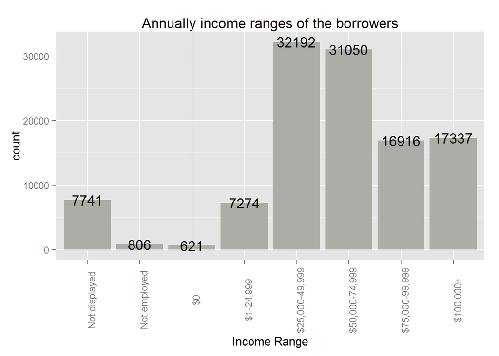

Most of the borrowers have income somewhere between $25,000 and $74,999. The number of borrowers who doesn’t belong to any income range is low (7741 without info) and only 806 are not employed.

**Monthly Loan Payment**

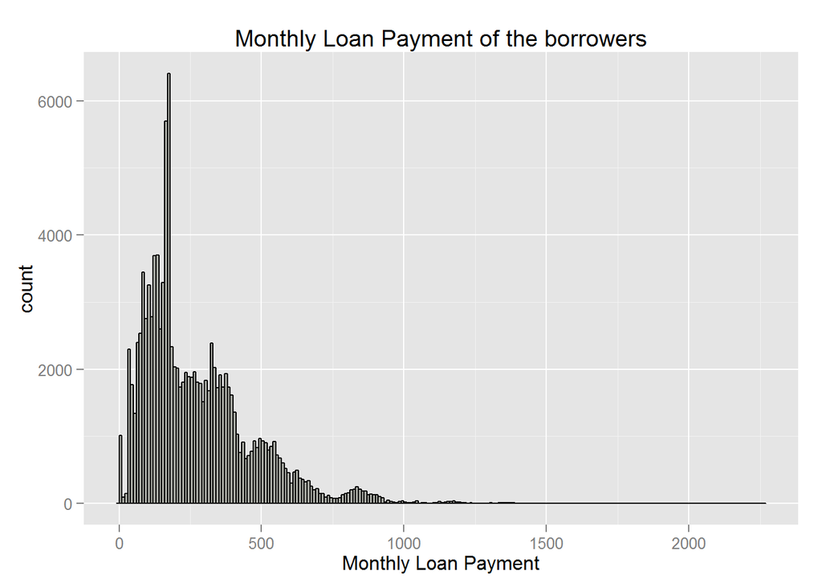

```
##    Min. 1st Qu.  Median    Mean 3rd Qu.    Max.
##     0.0   131.6   217.7   272.5   371.6  2252.0
```

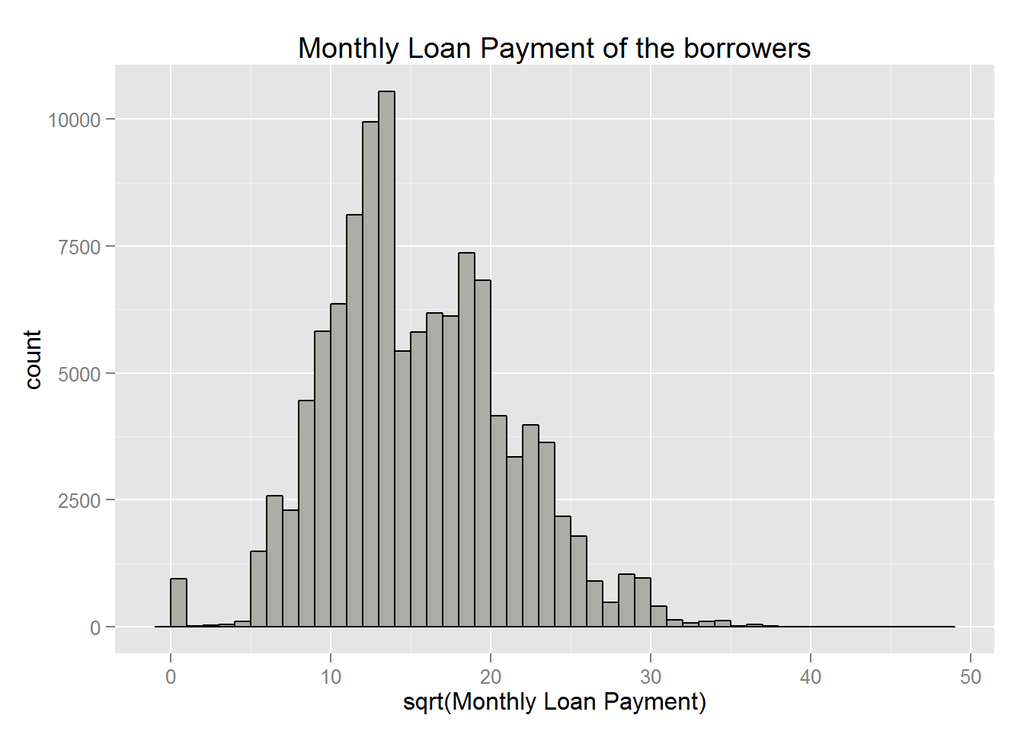

Borrowers mean monthly loan payment is $272.5. Median value is $217.7. Monthly Loan Payment had long-tailed distributions and so I’ve ploted the square root and the distribution looked more normal.

**How the Debt to Income is distributed?**

Let’s draw the histogram to get a better understanding of DIT(Debt to Income ) Ratio?.

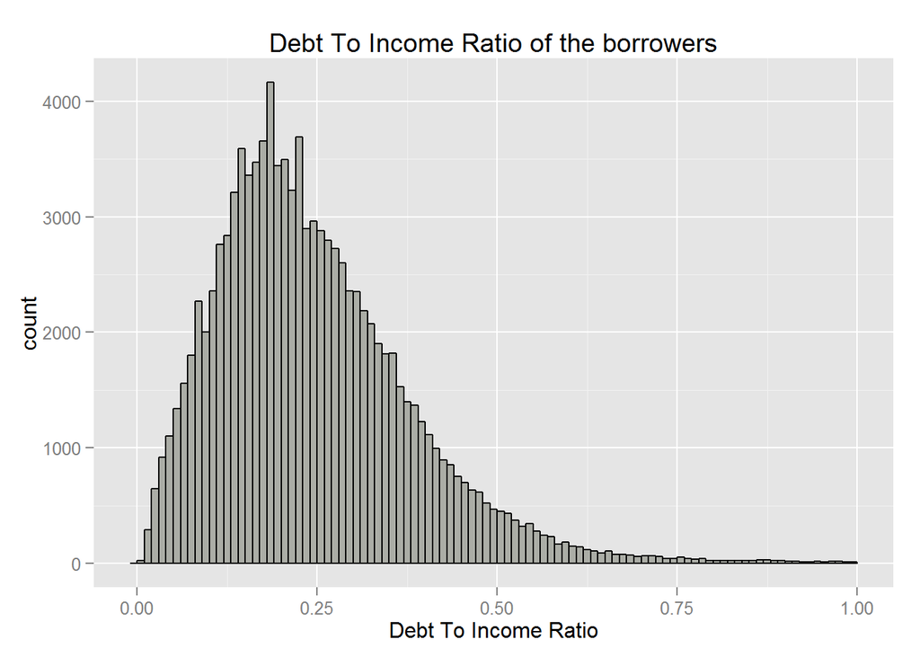

```
##    Min. 1st Qu.  Median    Mean 3rd Qu.    Max.    NA's
##   0.000   0.140   0.220   0.276   0.320  10.010    8554
```

For better visualization I’ve plotted only loans with DebtToIncomeRatio lower than 1. Most of the borrowers are trying to keep their Debt to Income Ratio bellow 0.32 (3rd quarter value).

**How is the Monthly Debt distributed?**

I’ve created new variable named Monthly Debt by multiplying the DebtToIncomeRatio and StatedMonthlyIncome.

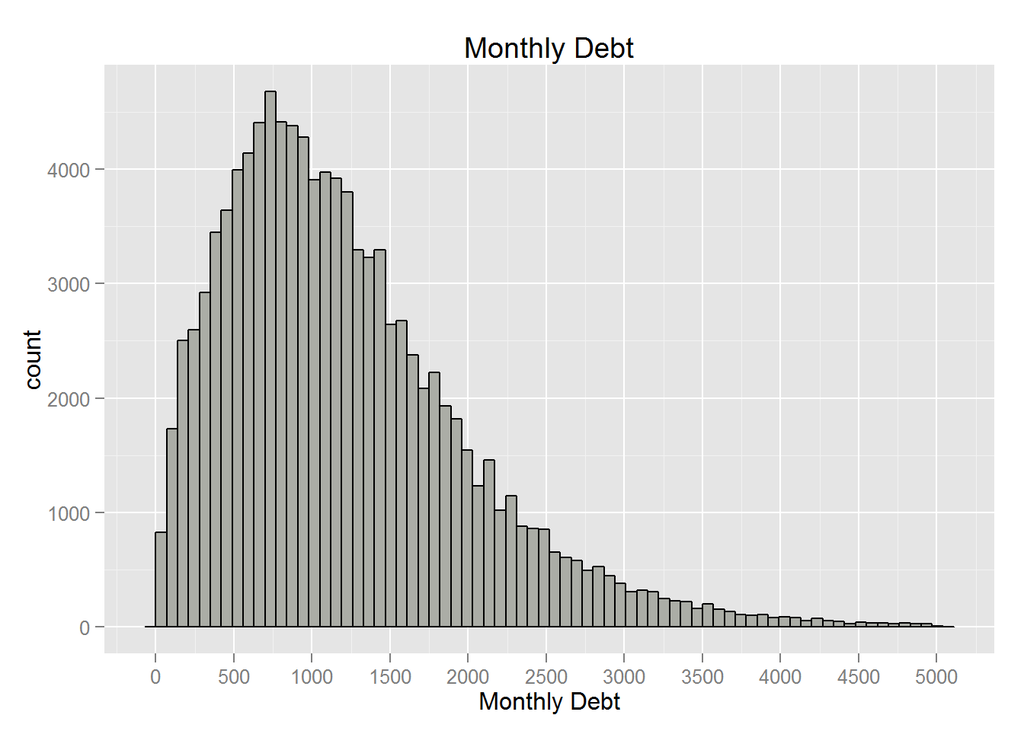

```
##     Min.  1st Qu.   Median     Mean  3rd Qu.     Max.     NA's
##      0.0    637.5   1062.0   1225.0   1622.0 171000.0     8554
```

```
##    Min. 1st Qu.  Median    Mean 3rd Qu.    Max.
##       0     635    1056    1205    1613    5000
```

Mean monthly debt for all record in this data set is 1225. It’s obvious that the max value of 171000 is outlier.The resulting distribution for loans with MonthlyDebt < 5000 is positively skewed with mean monthly debt of 1205.

**Whats the number of homeowners vs one that don’t own home?**

```
## Is Borrower Homeowner
## False  True
## 56459 57478
```

More than half are homeowners.57478 are owning home and 56459 are not home owners.

Next, I focused on borrower’s employment status and occupation. How borrower employment duration and employment status are related with the loans applications? What’s the most frequent Occupation of borrowers? Whic h are the top 10 Occupations between Prosper loans borrowers?

**When does a person apply for a loan in terms of the length of their working status?**

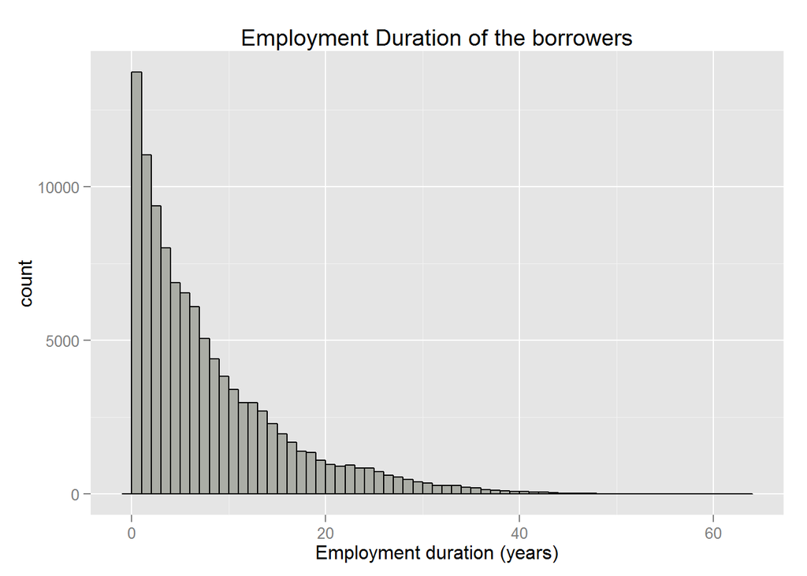

With the increase of the length of employment there is a very clear descending trend of the number of people who borrow loans. Probably the longer one works, the more one earns and is less likely to borrow loan.

**What’s the Employment status of the borrowers?**

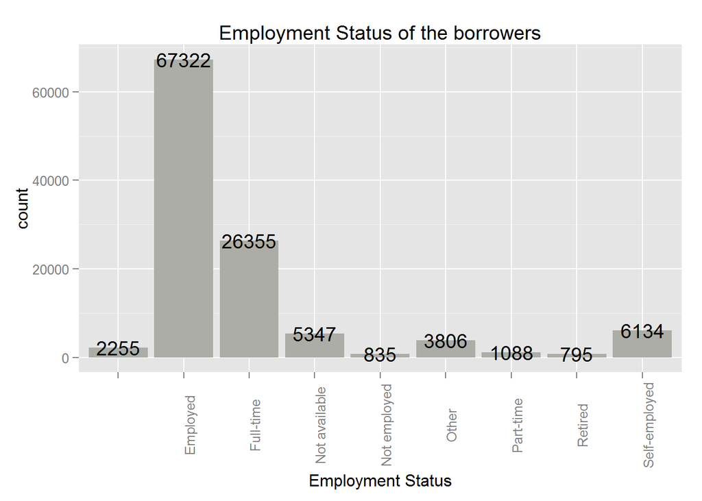

I’ve decided to create new variable to store whether one is employed or not. So everyone who has Employment Status as Employed, Full-time, Part-time or Self-employed I marked as employed, and all the other as unemployed.

```
##
##   employed unemployed
##     100899      13038
```

100899 of the loans have employed borrowers and only 13038 have not employed or no info for the employment status. This indicates that usually employed people are borrowing money.

**What’s the Occupation of borrowers in this dataset?**

For this purpose I’ve created new data frame named top10Occupations. This data set contains all loans where the occupation of the borrower is one of the top 10 occupations (Professional, Computer Programmer, Executive, Teacher, Administrative Assistant, Analyst, Sales - Commission, Accountant/CPA, Clerical and Sales - Retail).

```
## Source: local data frame [10 x 2]
##
##                  Occupation count
## 1                     Other 28617
## 2              Professional 13628
## 3       Computer Programmer  4478
## 4                 Executive  4311
## 5                   Teacher  3759
## 6  Administrative Assistant  3688
## 7                   Analyst  3602
## 8                            3588
## 9        Sales - Commission  3446
## 10           Accountant/CPA  3233
```

```
## Source: local data frame [10 x 2]
##
##                  Occupation count
## 1              Professional 13628
## 2       Computer Programmer  4478
## 3                 Executive  4311
## 4                   Teacher  3759
## 5  Administrative Assistant  3688
## 6                   Analyst  3602
## 7        Sales - Commission  3446
## 8            Accountant/CPA  3233
## 9                  Clerical  3164
## 10           Sales - Retail  2797
```

It looks like the data is incomplete for 28617 loans. 28617 loans have Other as value for occupation.

I want to check is there any relationship between the listing creatin year, employment status and occupation being empty.

```
##
## 2005 2006 2007 2008 2009 2010 2011 2012 2013 2014
##   23 2183   49    0    0    0    0    0  811  522
```

```
##
##           Full-time     Other
##      2255         1      1332
```

Based on the numbers occupation is empty for loans created between 2005 and 2007 where emploment status is empty, and for loans created in 2013 and 2014 when the employment status is Other.

I’ve excluded empty occupations and Other occupation option.

**Let’s plot the top 10 occupation.**

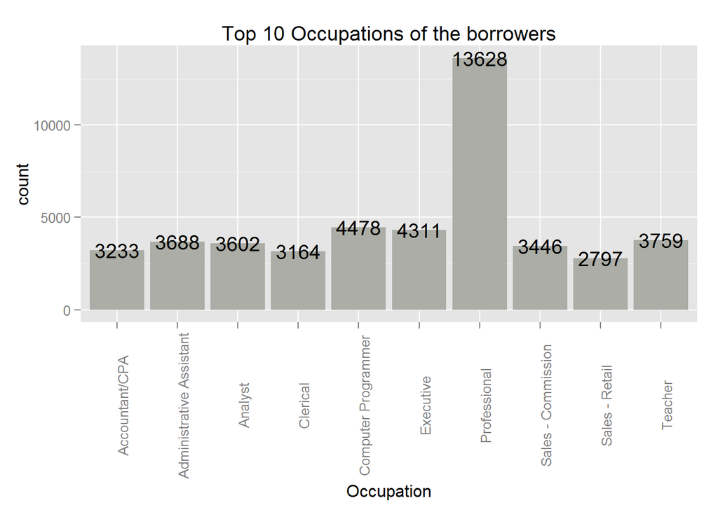

Occupation named Professional is the leader here.

Next, I’ve analyzed in which states borrowers live and which are the top 10 States?

**In which states borrowers live?**

I was very curious to analyse in which states borrowers live? Which are the top 10 States?

There are 5515 loans without state. I had some feeling that probably there is correlation between Listing Creation Date and State being empty. Let’s explore that. Let’s see when those 5515 loans are created. For that purpose I’ve created new data frame called loansWithoutState which contains the loans where the state is empty.

```
##
## 2005 2006 2007 2008 2009 2010 2011 2012 2013 2014
##   23 3137 2332   23    0    0    0    0    0    0
```

All of the loans without borrower state info are created before 2009. It looks like the Borrower State info had become required field value after 2009.

**Let’s plot the top 10 states.**

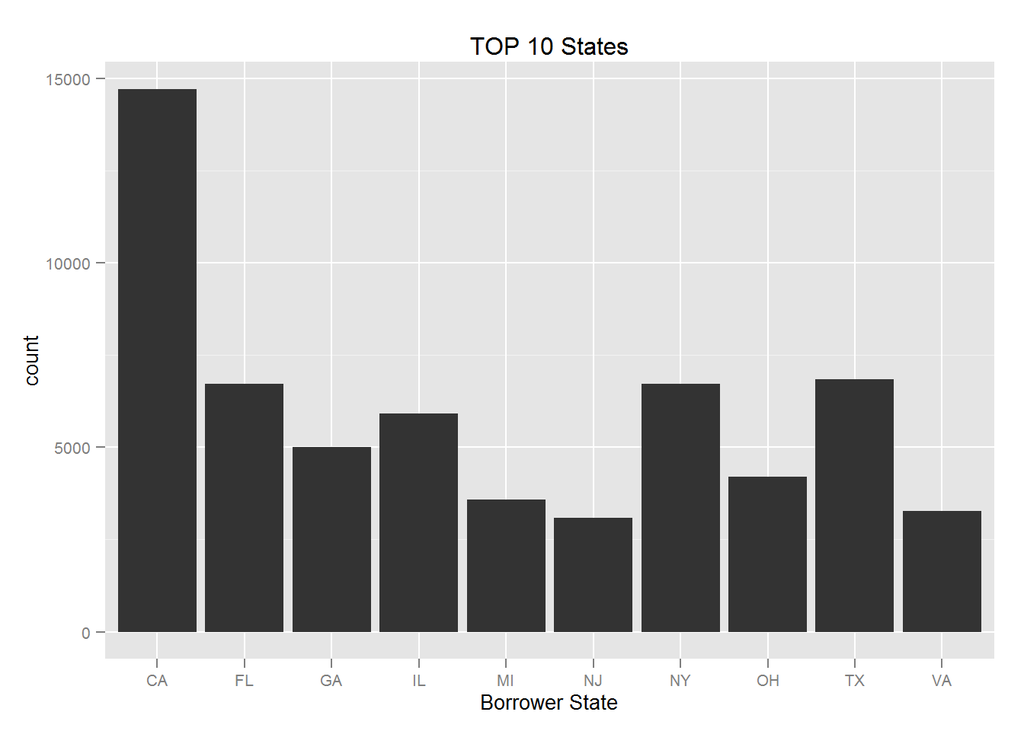

On this plot we can see that California is leader followed by Texas, New York, Florida, Illinois and Georgia with more than 5000 Prosper loans.

Next I’ve analyzed some Prosper values and other values that I was curious to learn about.

**Prosper Ratings**

Every loan application is assigned a Prosper Rating, which allows to maintain consistency in the evaluation process. Prosper Ratings allow potential investors to easily consider a loan application’s level of risk because the rating represents an estimated average annualized loss rate range to the investor. (www.prosper.com)

Prosper Rating - Estimated Avg. Annual Loss Rate:

- AA - 0.00 - 1.99%
- A - 2.00 - “3.99%
- B - 4.00 - “5.99%
- C - 6.00 - “8.99%
- D - 9.00 - “11.99%
- E - 12.00 - “14.99%
- HR >= 15.00%

**What’s the Prosper Rating for the borrowers in this dataset?**

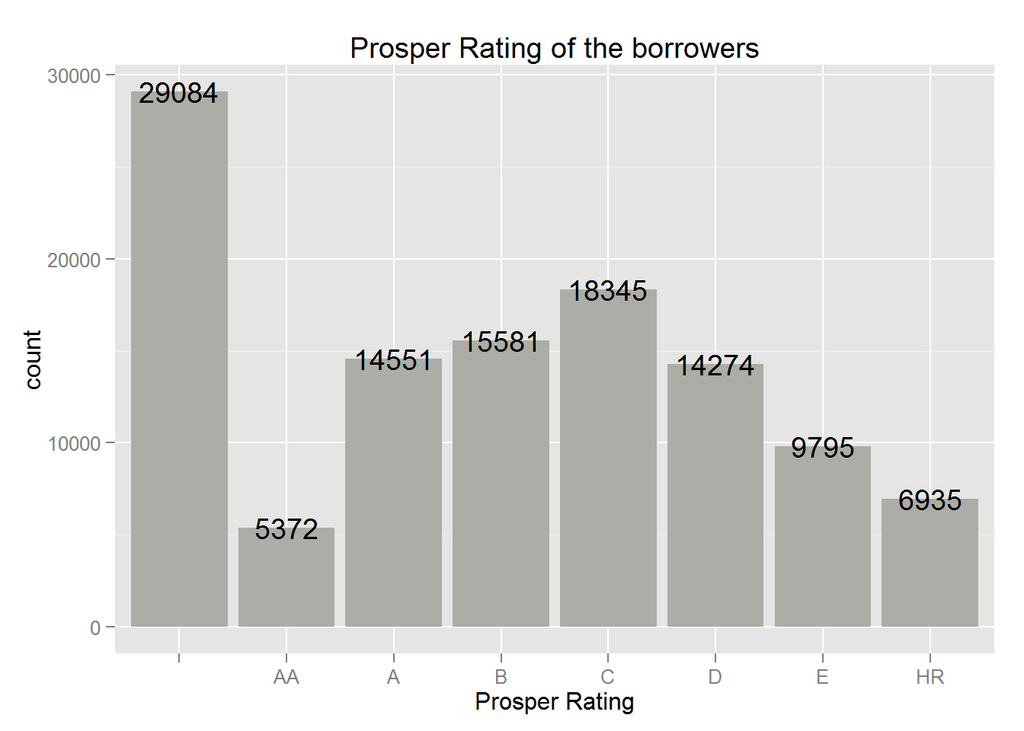

Most of the borrowers have prosper rating between A and D. AA is the most rare Prosper Rating

All 29084 loans that have no Prosper Rating are the one created before July 1st 2009.

**Let’s explore the Prosper Score of borrowers in this dataset?**

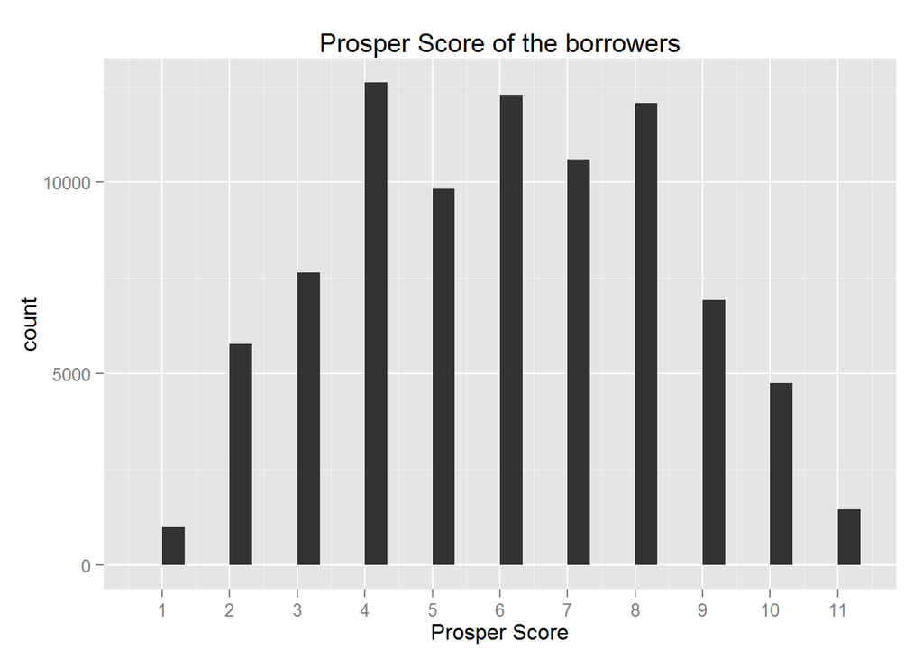

```
##    Min. 1st Qu.  Median    Mean 3rd Qu.    Max.    NA's
##    1.00    4.00    6.00    5.95    8.00   11.00   29084
```

Prosper scores are normally distributed mean=5.95 and median 6.

**What is the min, max, median and mean of the other Prosper Loans borrowers have?**

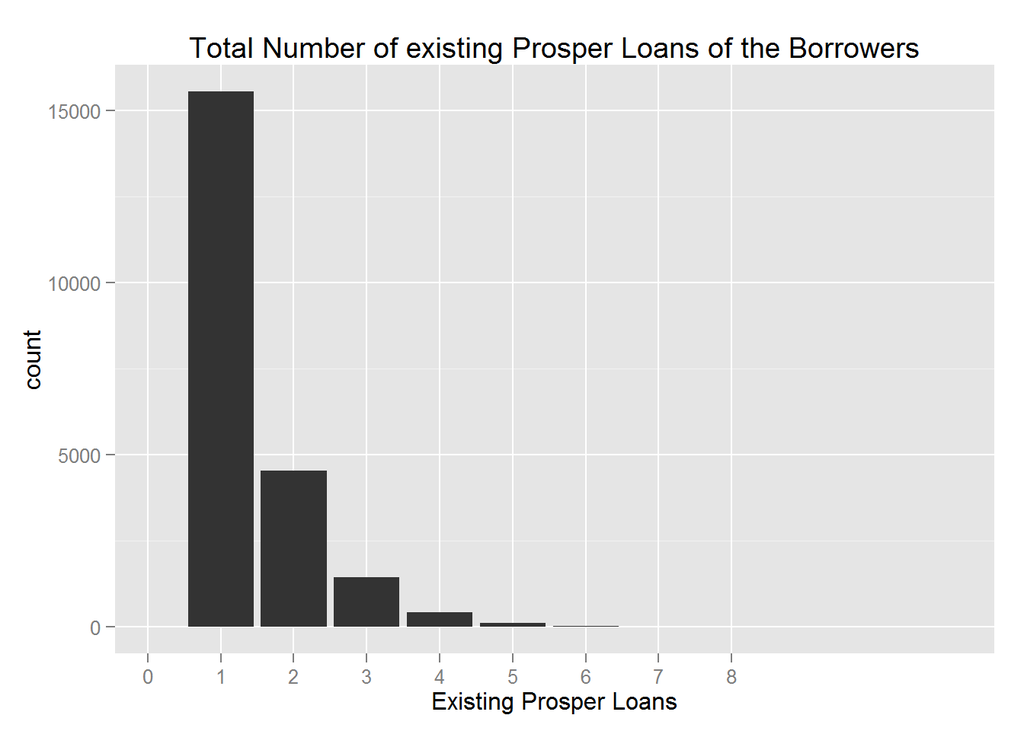

```
##    Min. 1st Qu.  Median    Mean 3rd Qu.    Max.    NA's
##    0.00    1.00    1.00    1.42    2.00    8.00   91852
```

As we can see borrowers have max 8 other additional Prosper loans, and mostly less than 2 additional prosper loans.

**How many lenders usually are sharing the risk together?**

```
##    Min. 1st Qu.  Median    Mean 3rd Qu.    Max.
##    1.00    2.00   44.00   80.48  115.00 1189.00
```

We can notice that there is huge difference between 3rd Qu. and Max. value, so it looks like the Max value is outlier. Mean number of investors is around 80.48 and median 44.

**How many loans have recommendations?**

```
##
##      0      1      2      3      4      5      6      7      8      9
## 109678   3516    568    108     26     14      4      5      3      6
##     14     16     18     19     21     24     39
##      1      2      2      1      1      1      1
```

109678 loans don’t have recommendations. Recommendations are not so popular in the loans applications.

**How lenders benefit from investing in loans?**

```
##    Min. 1st Qu.  Median    Mean 3rd Qu.    Max.
## -0.0100  0.1242  0.1730  0.1827  0.2400  0.4925
```

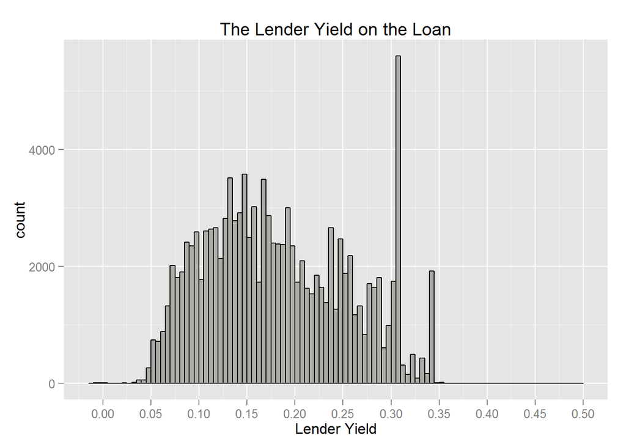

Most yields is between 0.05 and 0.35. The highest peak in the graphic is around 0.31.

# Univariate Analysis

### What is the structure of your dataset?

For the purpose of this project I am using the Prosper data set provided as part of this course, which contains all Prosper loans created until March 11th, 2014. It’s tidy data sets, since each variable is a column and each row is an observation. There are discrete and continuous variables.

```
## [1] 113937     85
```

### What is/are the main feature(s) of interest in your dataset?

In my analysis the main features of interest are:

- **Number of investors** which can help me to determinate which loans are attractive for investing. What are the main characteristics of those loans?
- **Borrower rate** is another variable that is my feature of interest. I really want to learn when borrower rate is lower and when higher.
- **Listing Creation Date** which can help me to understand more about the Prosper business and how loans are distributed over the years.

Prosper Score, Income Range, Loan amount, Loan Category and Term are also part of my main features group.

### What other features in the dataset do you think will help support your investigation into your feature(s) of interest?

Other variables that can help me to support my investigation are Credist Score, Debt To Income Ratio, Prosper Rating, Occupation, Employment Status and Employment Duration.

### Did you create any new variables from existing variables in the dataset?

I created following new variables during the analysis: ListingCretionYear, MonthlyDebt, EmploymentInfo, ListingCategoryName.

### Of the features you investigated, were there any unusual distributions? Did you perform any operations on the data to tidy, adjust, or change the form of the data? If so, why did you do this?

If I was not aware of the global financial crisis in 2009 for me the high decrease of the number of the loans would be unusual distribution. I didn’t face with any surprising about the distributions during the initial analysis.

I set ListingCreationYear variable as a factor so when I plotted it would look discrete. I’ve alose taked care of ranked variables order and variables types.

# Bivariate Plots Section

I was very curious to learn which loans are attractive for investors? When more people are sharing the risk for one loan? So I’ve decided to plot couple of values vs Number of investors.

## Number of Investors Analysis

**Are Number of Investors and Prosper Score related. Do we have more investors if Prosper Score is higher?**

```
## Number of loans per prospre score
##     1     2     3     4     5     6     7     8     9    10    11
##   992  5766  7642 12595  9813 12278 10597 12053  6911  4750  1456
```

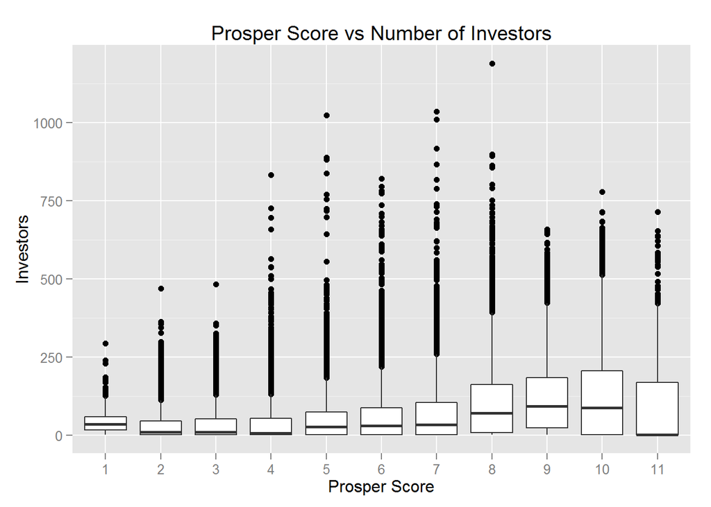

Let’s try to plot mean investors value for each prosper score and see how it looks like.

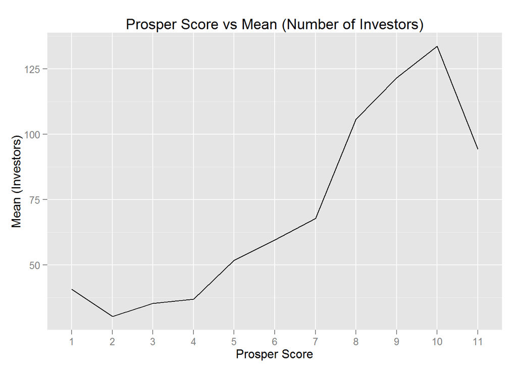

The number of investors is growing when prosper score is higher. The peak is reached for prosper score equal to 10. In this case I’ve used the subset of all loans created after July 1st 2009 (loansAfter20090701) since this property was not available for loans created before that date.

**Is there any relationship between Loan Original Amount and Number of Investors**

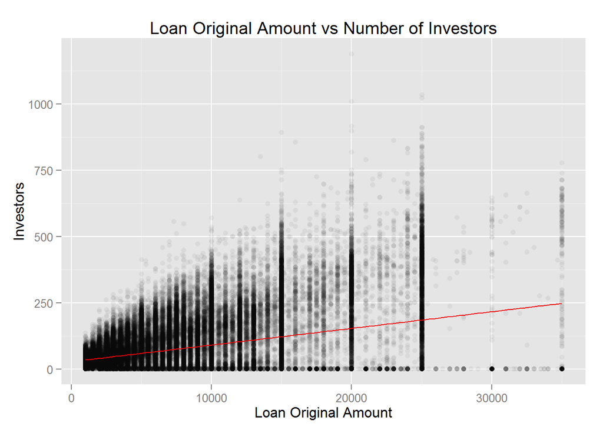

Larger loans have more investors. Again we can see picks for amount values of 5000, 10000, 15000, etc…

**Are Number of Investors and Number of Prosper Loans related? Do we have more investors if the Borrower already have Prosper Loans**

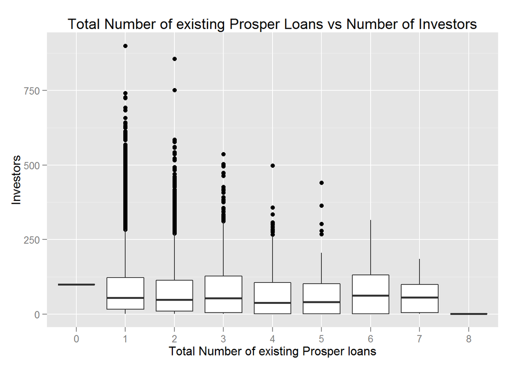

```
##    Min. 1st Qu.  Median    Mean 3rd Qu.    Max.    NA's
##    0.00    1.00    1.00    1.42    2.00    8.00   91852
```

The number of investors on one loan is higher if the borrower have less existing prosper loans.

I would love to create one more plot, with the mean values of the Total prosper loan values.

```
## Source: local data frame [9 x 4]
##
##   TotalProsperLoans investors_mean investors_median     n
## 1                 0       99.00000             99.0     1
## 2                 1       85.50219             55.0 15538
## 3                 2       79.16498             48.0  4540
## 4                 3       80.86317             53.0  1447
## 5                 4       66.91127             38.0   417
## 6                 5       68.22115             40.5   104
## 7                 6       81.96552             63.0    29
## 8                 7       67.00000             56.5     8
## 9                 8        1.00000              1.0     1
```

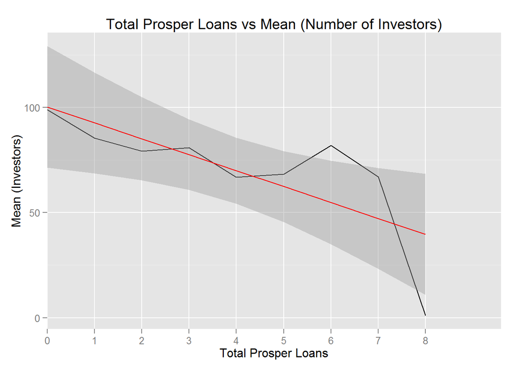

On this plot we can see the same trend as on the previous plot, where more existing prosper loans leads to lower mean value of number of investors.

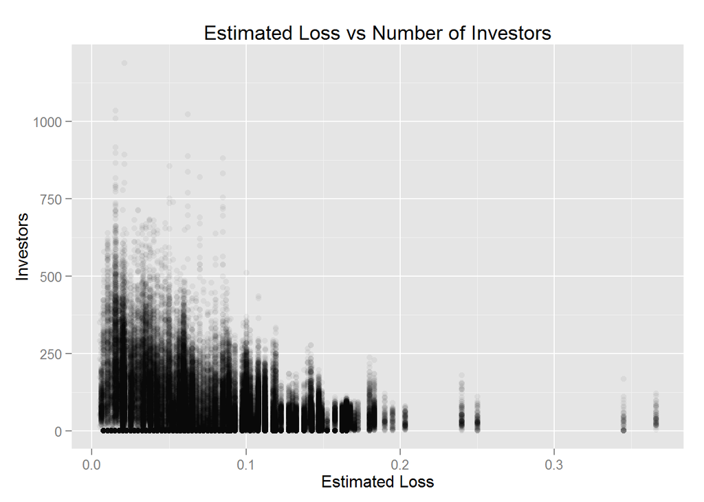

```
##
##  Pearson's product-moment correlation
##
## data:  ploans$EstimatedLoss and ploans$Investors
## t = -83.4819, df = 84851, p-value < 2.2e-16
## alternative hypothesis: true correlation is not equal to 0
## 95 percent confidence interval:
##  -0.2817071 -0.2692716
## sample estimates:
##        cor
## -0.2755009
```

Smaller estimated loss is always more attractive for investing. That’s why smaller estimated loss values usually have more investors.

## Laon Amount Analysis

Next, I was curious to learn is there any relationship between the loan amount and other values in this data set. Let’s see couple of them.

**How borrowed loan amount vary trought the years?**

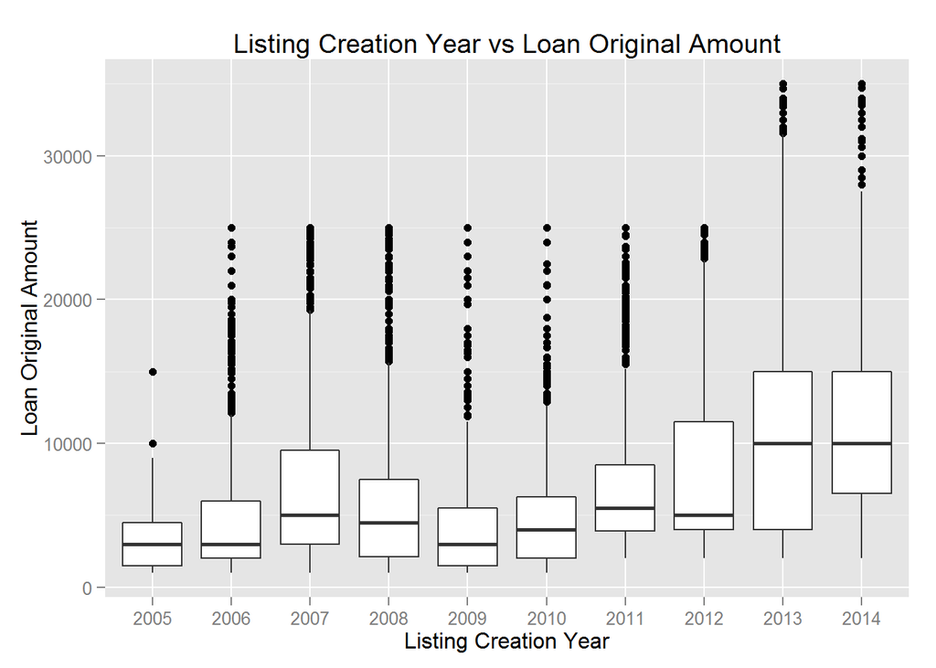

```
## ploans$ListingCreationYear: 2005
##    Min. 1st Qu.  Median    Mean 3rd Qu.    Max.
##    1000    1500    3000    3856    4500   15000
## --------------------------------------------------------
## ploans$ListingCreationYear: 2006
##    Min. 1st Qu.  Median    Mean 3rd Qu.    Max.
##    1000    2000    3001    4845    6000   25000
## --------------------------------------------------------
## ploans$ListingCreationYear: 2007
##    Min. 1st Qu.  Median    Mean 3rd Qu.    Max.
##    1000    3000    5000    7067    9500   25000
## --------------------------------------------------------
## ploans$ListingCreationYear: 2008
##    Min. 1st Qu.  Median    Mean 3rd Qu.    Max.
##    1000    2100    4500    5965    7500   25000
## --------------------------------------------------------
## ploans$ListingCreationYear: 2009
##    Min. 1st Qu.  Median    Mean 3rd Qu.    Max.
##    1000    1500    3000    4393    5500   25000
## --------------------------------------------------------
## ploans$ListingCreationYear: 2010
##    Min. 1st Qu.  Median    Mean 3rd Qu.    Max.
##    1000    2000    4000    4842    6300   25000
## --------------------------------------------------------
## ploans$ListingCreationYear: 2011
##    Min. 1st Qu.  Median    Mean 3rd Qu.    Max.
##    2000    3907    5500    6704    8500   25000
## --------------------------------------------------------
## ploans$ListingCreationYear: 2012
##    Min. 1st Qu.  Median    Mean 3rd Qu.    Max.
##    2000    4000    5000    7877   11510   25000
## --------------------------------------------------------
## ploans$ListingCreationYear: 2013
##    Min. 1st Qu.  Median    Mean 3rd Qu.    Max.
##    2000    4000   10000   10610   15000   35000
## --------------------------------------------------------
## ploans$ListingCreationYear: 2014
##    Min. 1st Qu.  Median    Mean 3rd Qu.    Max.
##    2000    6500   10000   11920   15000   35000
```

Mean loans amounts decreased in 2009 to 4393 and reached the top value in 2013/2014 (10610/11920).

**How loan amount and term are related? Let’s plot them.**

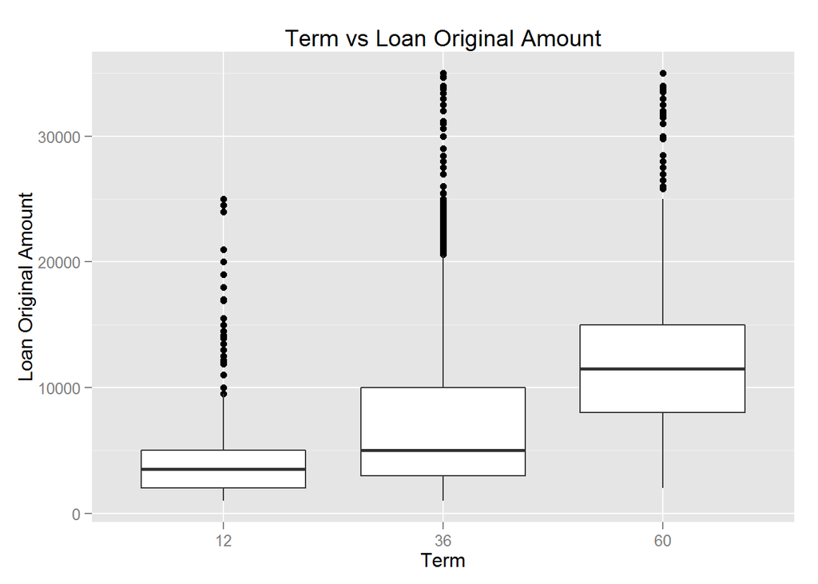

```
## ploans$Term: 12
##    Min. 1st Qu.  Median    Mean 3rd Qu.    Max.
##    1000    2000    3500    4694    5000   25000
## --------------------------------------------------------
## ploans$Term: 36
##    Min. 1st Qu.  Median    Mean 3rd Qu.    Max.
##    1000    3000    5000    7276   10000   35000
## --------------------------------------------------------
## ploans$Term: 60
##    Min. 1st Qu.  Median    Mean 3rd Qu.    Max.
##    2000    8000   11500   12370   15000   35000
```

When the term is longer then the loan amounts are larger. Median and mean values are growing as the term is growing.

**Let’s see how loan amount is related to the IncomeRange?**

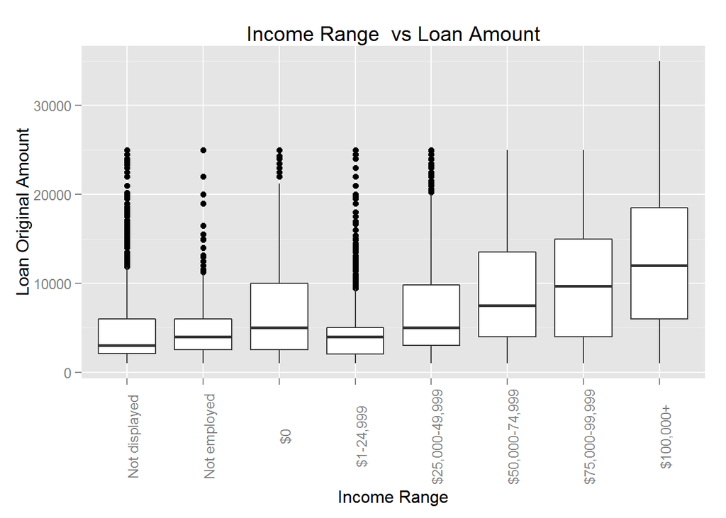

Larger loans on average are related to larger incomes.

**Let’s see how the Employment Status is related to the loan amount.**

For this purpose we are going the use the newly created variable EmploymentInfo.

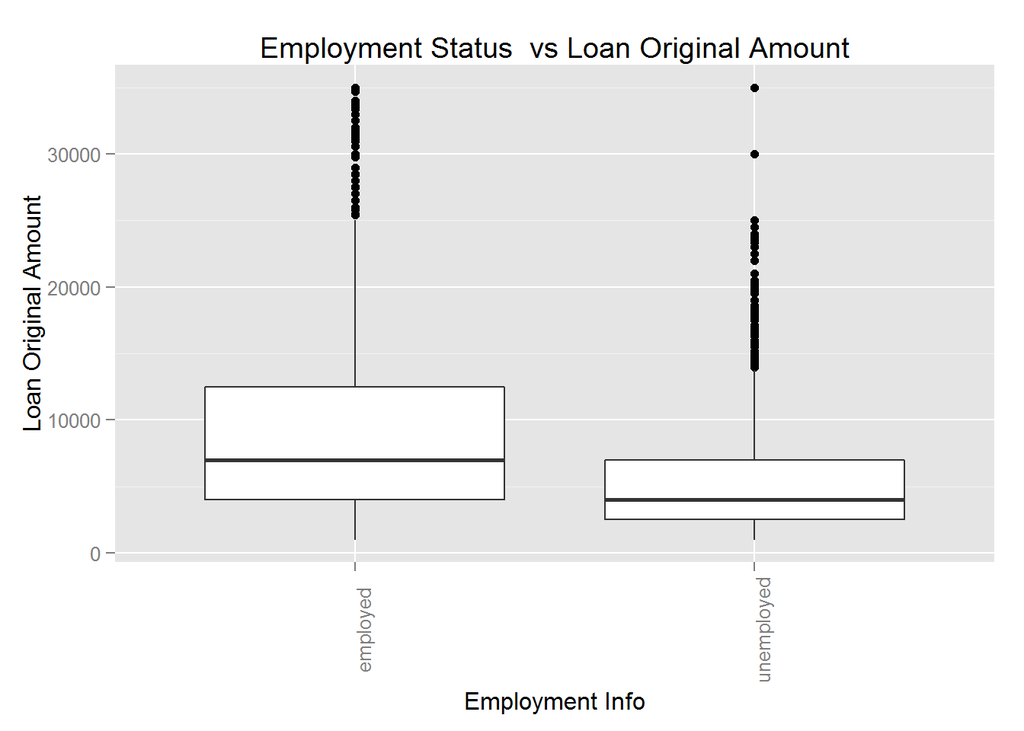

Employed people are borrowing more money then unemployed.

## Other Variables Analysis

**Monthly Debt vs Current Credit Lines**

Let’s see how number of credit lines and monthly debt are related.

Current Credit Lines

```
##    Min. 1st Qu.  Median    Mean 3rd Qu.    Max.    NA's
##    0.00    7.00   10.00   10.32   13.00   59.00    7604
```

MonthlyDebt

```
##     Min.  1st Qu.   Median     Mean  3rd Qu.     Max.     NA's
##      0.0    637.5   1062.0   1225.0   1622.0 171000.0     8554
```

[figure not shown]

```
##
##  Pearson's product-moment correlation
##
## data:  ploans$CurrentCreditLines and ploans$MonthlyDebt
## t = 168.1152, df = 97901, p-value < 2.2e-16
## alternative hypothesis: true correlation is not equal to 0
## 95 percent confidence interval:
##  0.4684282 0.4781498
## sample estimates:
##       cor
## 0.4733034
```

As the number of credit lines is increased, debt is growing. We have positive correlation of 0.47.

# Bivariate Analysis

### Talk about some of the relationships you observed in this part of the investigation. How did the feature(s) of interest vary with other features in the dataset?

The number of investors is growing when the prosper score is higher, loan amount is bigger, borrowers have less existing prosper loans, estimated loss is lower.

The mean loan amount vary trough years. The lowest mean was $4393 in 2009 and the top mean value is in 2013/2014 ($10610/$11920) Higher loan amounts have longer term, and they are related to employed borrowers with larger incomes.

### Did you observe any interesting relationships between the other features (not the main feature(s) of interest)?

I’ve observed that employed people are borrowing more money and as the number of credit lines is increasing, debt is growing.